# Blog Post 3

RRRRR

2022-10-28

## Adding What we Did From Last Time

```r
# load tidyverse
suppressPackageStartupMessages(library(tidyverse))

#load data
HighwayRail<-read_csv(here::here("dataset-ignore", "Highway-Rail_Grade_Crossing_Accident_Data.csv"), show_col_types = FALSE)
#only keep data in MA
HighwayRail_MA <- HighwayRail %>%
  filter(`State Name` == "MASSACHUSETTS")

#select necessary column names for MA in original dataset
MA_select <- HighwayRail_MA %>%
  select(`Report Year`, Date,   Month, Day, Hour, Minute, `AM/PM`, Time, `Nearest Station`,     Subdivision,    `County Name`, `State Name`,`Highway Name`,`Public/Private Code`, `Public/Private`, `Highway User`, `Estimated Vehicle Speed`,`Vehicle Direction`,  `Highway User Position`,`Equipment Involved`, `Equipment Struck`, Temperature, Visibility, `Weather Condition`, `Number of Locomotive Units`, `Number of Cars`, `Train Speed`, `Estimated/Recorded Speed`,   `Train Direction`, `Crossing Warning Expanded 1`,`Crossing Warning Expanded 2`,`Crossing Warning Expanded 3`,`Crossing Warning Expanded 4`,`Crossing Warning Expanded 5`,`Crossing Warning Expanded 6`,`Crossing Warning Expanded 7`,`Crossing Warning Expanded 8`,`Crossing Warning Expanded 9`, `Crossing Warning Expanded 10`, `Crossing Warning Expanded 11`,  `Crossing Warning Expanded 12`, `Signaled Crossing Warning Code`, `Signaled Crossing Warning`, `Roadway Condition`, `Crossing Warning Location`,    `Warning Connected To Signal`, `Crossing Illuminated`,`User Age`,`User Gender`,`User Struck By Second Train`, `Highway User Action`, `View Obstruction`, `Driver Condition`, `Driver In Vehicle`, `Crossing Users Killed For Reporting Railroad`, `Crossing Users Injured For Reporting Railroad`, `Vehicle Damage Cost`,   `Employees Killed For Reporting Railroad`, `Employees Injured For Reporting Railroad`, `Passengers Killed For Reporting Railroad`, `Passengers Injured For Reporting Railroad`, Narrative)
head(MA_select, n=10)
```

```
## # A tibble: 10 × 62
##    Report…¹ Date  Month Day   Hour  Minute `AM/PM` Time  Neare…² Subdi…³ Count…⁴
##       <dbl> <chr> <chr> <chr> <chr> <chr>  <chr>   <tim> <chr>   <chr>   <chr>
##  1     1986 06/3… 06    30    10    28     AM      10:28 WARREN  <NA>    WORCES…
##  2     1986 11/2… 11    25    05    30     PM      17:30 NORWOOD <NA>    NORFOLK
##  3     1986 11/2… 11    21    05    15     AM      05:15 READVI… <NA>    NORFOLK
##  4     1986 11/2… 11    21    02    26     AM      02:26 PALMER  <NA>    HAMPDEN
##  5     1986 11/1… 11    11    05    15     PM      17:15 WILLIA… <NA>    HAMPDEN
##  6     1986 12/1… 12    18    11    45     PM      23:45 LAWREN… <NA>    ESSEX
##  7     1986 12/0… 12    04    11    08     AM      11:08 BEVERLY <NA>    ESSEX
##  8     1986 03/0… 03    04    09    11     AM      09:11 CHESTER <NA>    HAMPDEN
##  9     1986 11/2… 11    20    01    58     PM      13:58 REVERE  <NA>    SUFFOLK
## 10     1986 09/2… 09    29    06    33     AM      06:33 FRAMIN… <NA>    MIDDLE…
## # … with 51 more variables: `State Name` <chr>, `Highway Name` <chr>,
## #   `Public/Private Code` <chr>, `Public/Private` <chr>, `Highway User` <chr>,
## #   `Estimated Vehicle Speed` <dbl>, `Vehicle Direction` <chr>,
## #   `Highway User Position` <chr>, `Equipment Involved` <chr>,
## #   `Equipment Struck` <chr>, Temperature <dbl>, Visibility <chr>,
## #   `Weather Condition` <chr>, `Number of Locomotive Units` <dbl>,
## #   `Number of Cars` <dbl>, `Train Speed` <dbl>, …
```

## Exploratory Data Analysis

When we select the state name Massachusetts as the main subject that we are researching on, the output returns 1017 rows of results, years ranging from 1986 to 2021. And most of the columns aren’t statistical, since many of them are explanations of how the accidents happened. The first thing we want to do with this subset is research the statistical data and see if these are the reasons causing the incidents, for example, temperature, vehicle speed, visibility… We first filtered any “NA” in the `Weather Condition` and Temperature columns. Also, we first plotted the weather condition by temperature and fill it with the count of accidents, and we found an outlier for the temperature that is over 400 F. To clean the data, we filtered the data that are less or equal to the historic highest temperature in MA, which is 104 F.

## How We Clean the Data

```r
# filter out missing values, Temperature higher than 104
MA_select2 <- MA_select %>% filter(!is.na(`Weather Condition`) & !is.na(Temperature) & !is.na(Visibility), Temperature <= 104)

# summary data
summary(MA_select2$Temperature)
```

```
##    Min. 1st Qu.  Median    Mean 3rd Qu.    Max.
##  -10.00   30.00   45.00   46.64   64.00  100.00
```

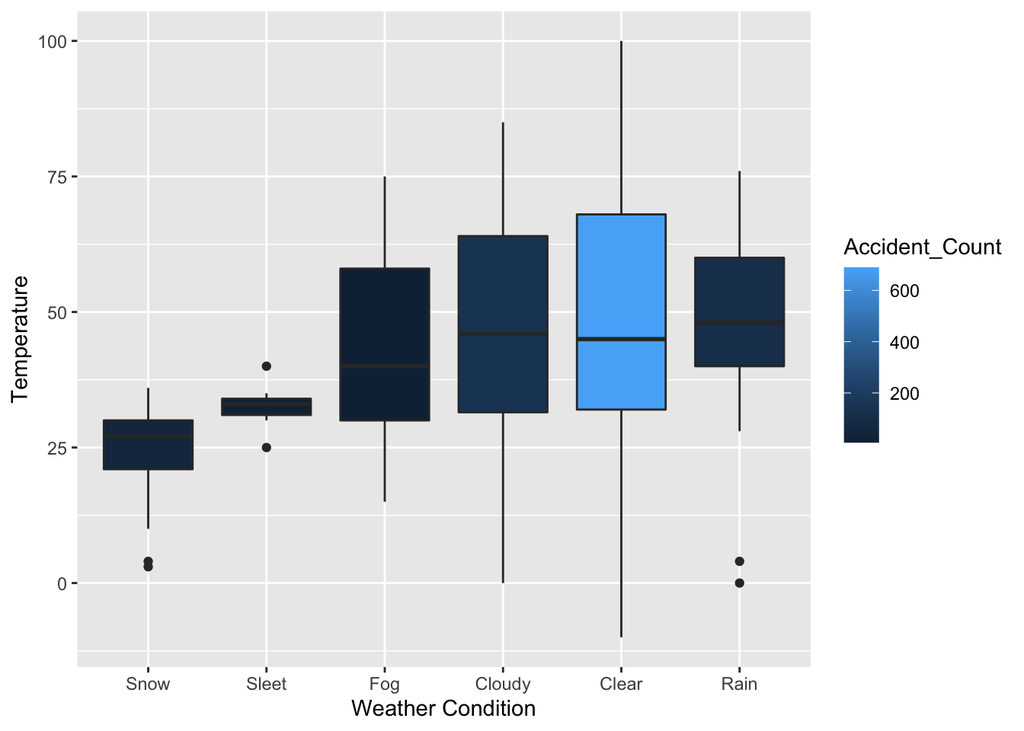

```r
# boxplot for weather conditions, Temperature and accident number
MA_select2 %>% group_by(`Weather Condition`) %>% mutate(Accident_Count = n()) %>%
  ggplot(aes(x = reorder(`Weather Condition`, Temperature, decreasing=FALSE), y = Temperature, fill = Accident_Count)) + geom_boxplot() + labs(x = "Weather Condition")
```

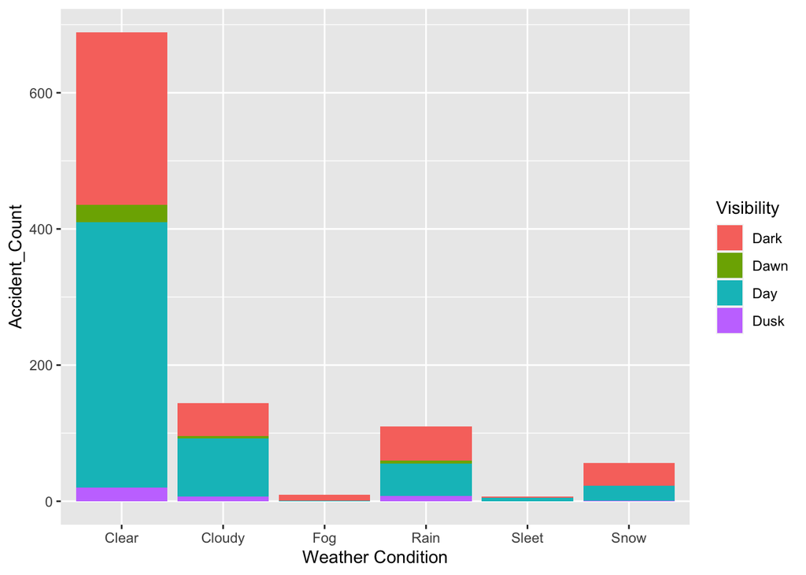

```r
# plot to show the percentage of car accidents for different visibility in different weather conditions
MA_select2 %>% group_by(`Weather Condition`) %>% mutate(Accident_Count = n()) %>%
  ggplot(aes(x = `Weather Condition`, fill = Visibility)) + geom_bar() + labs(y = "Accident_Count")
```

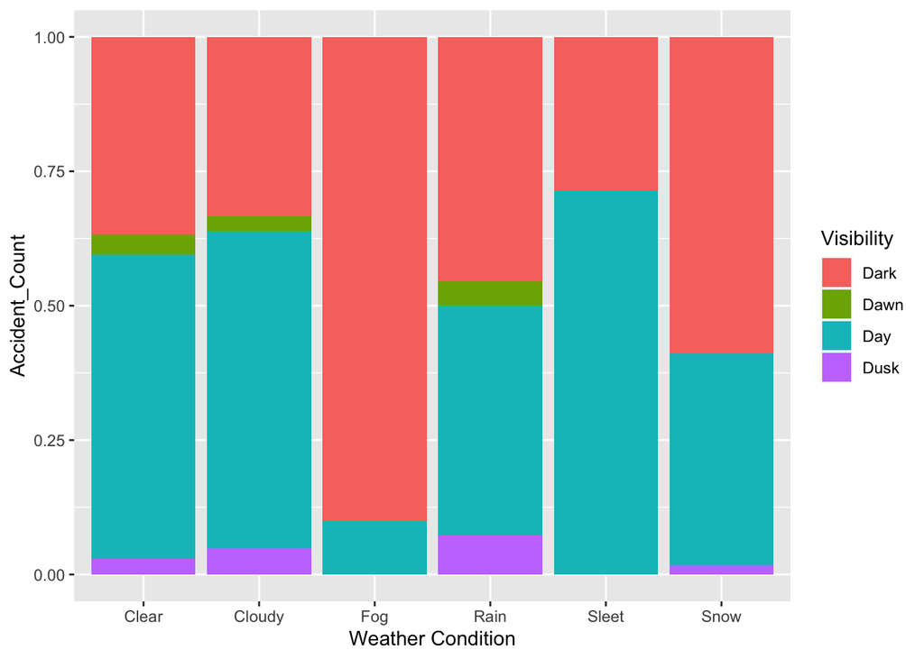

```r
# plot to show the number of car accidents for different visibility in different weather conditions
MA_select2 %>% group_by(`Weather Condition`) %>% mutate(Accident_Count = n()) %>%
  ggplot(aes(x = `Weather Condition`, fill = Visibility)) + geom_bar(position = "fill") + labs(y = "Accident_Count")
```

For the second and third graphs, we found there is no NA value from the visibility column. Both graphs show that in foggy weather, the probability of accidents is significantly large at dark, and in all weather conditions, the proportions of accidents that happened at dusk and dawn are the lowest.